# Homework2

1. Use the Lending Club Data posted under “Data and Code” under the page labelled “Module 2: ML Applications in Finance (Week 2)”
2. Refer now to slide 4 of the “02.06- Supervised Learning_DecisionTrees -Credit Application” slide deck. Consider 11 potential values of the threshold X, starting with $34,000 and increasing in increments of $8,600 up to $120,000. In other words, $34,000, $42,600, …, $11,140, $120,000. For each of these values find the corresponding values for 𝑃 , 𝑃 , and 𝑃 , and expected entropy associated with the income feature. Display the results in tabular form with column headers 𝑋, 𝑃 , 𝑃 , 𝑃 , and 𝐸 . Out of the possible values of X considered here, which would you pick to make income a good candidate for the root node?

```python
# Create the directory
import os
print(os.getcwd())

# Set the working directory
os.chdir('/Users/surajgurung/Library/CloudStorage/OneDrive-UniversityofFlorida/AI&FINtech/CreditApplication')

# list the name of variables located their
print(os.listdir())
```

```
/Users/surajgurung/Library/CloudStorage/OneDrive-UniversityofFlorida/AI&FINtech/Project2
['.DS_Store', 'anaconda_projects', 'Homework2', 'LendingClub_Decision_Trees_Training_Set.xlsx', 'README.md', 'Logistic_Regression.ipynb', '.virtual_documents', '.ipynb_checkpoints', 'Decision_trees.ipynb', '.git', 'Project2', 'LendingClub_Decision_Trees_Test_Set.xlsx', 'LendingClub_Decision_Trees_Va…
```

```python
## Upload the library
# The Libraries                                                                                # Version
import pandas as pd                                                                            # 1.3.4
import numpy as np                                                                             # 1.20.3
import scipy.stats as stats                                                                    # 0.12.2
from sklearn.linear_model import LogisticRegression                                            # 0.24.2
from sklearn import metrics
from sklearn.tree import DecisionTreeClassifier, plot_tree
from IPython.display import Image
from sklearn.metrics import accuracy_score, recall_score, precision_score, f1_score
from sklearn.metrics import confusion_matrix, classification_report, roc_auc_score
from sklearn.metrics import roc_curve, auc
from sklearn.model_selection import cross_val_predict
from sklearn.compose import ColumnTransformer
from sklearn.pipeline import Pipeline
from sklearn.impute import SimpleImputer
from sklearn.preprocessing import StandardScaler, OneHotEncoder
import matplotlib.pyplot as plt
```

```python
# Load the dataset
train = pd.read_excel('/Users/surajgurung/Library/CloudStorage/OneDrive-UniversityofFlorida/AI&FINtech/CreditApplication/LendingClub_Decision_Trees_Training_Set.xlsx')
validation=pd.read_excel('/Users/surajgurung/Library/CloudStorage/OneDrive-UniversityofFlorida/AI&FINtech/CreditApplication/LendingClub_Decision_Trees_Validation_Set.xlsx')
test = pd.read_excel('/Users/surajgurung/Library/CloudStorage/OneDrive-UniversityofFlorida/AI&FINtech/CreditApplication/LendingClub_Decision_Trees_Test_Set.xlsx')
```

```python
# 1 = good, 0 = default
print(train.head())
print("----------------------")
print(validation.head())
print("----------------------")# remove target column to create feature only dataset
X_train = train.drop('loan_status',axis=1)
X_val=validation.drop('loan_status',axis=1)
X_test=test.drop('loan_status',axis=1)

# store target column
y_train = train['loan_status']
y_val=validation['loan_status']
y_test=test['loan_status']

print(X_train.shape, y_train.shape, X_val.shape,y_val.shape,X_test.shape,y_test.shape)
```

```
   home_ownership    income    dti  fico  loan_status
0               1   44304.0  18.47   690            0
1               0   50000.0  29.62   735            1
2               0   64400.0  16.68   675            1
3               0   38500.0  33.73   660            0
4               1  118000.0  26.66   665            1
----------------------
   home_ownership    income    dti  fico  loan_status
0               0   25000.0  27.60   660            0
1               0   50000.0  21.51   715            1
2               1  100000.0   8.14   770            1
3               0   75000.0   1.76   685            0
4               1   78000.0  16.11   680            1
----------------------
(7000, 4) (7000,) (3000, 4) (3000,) (2290, 4) (2290,)
```

```python
# Calculate the Proportion of income in training set greater than X (P1)

# Define the thresholds as a list or array
thresholds = [34000, 42600, 51200, 59800, 68400, 77000, 85600, 94200, 102800, 111400, 120000]

# Store results
result_P1 = []

for x in thresholds:
    P1_greater = (train['income'] > x).mean()
    result_P1.append([x, P1_greater])

# Convert to DataFrame
p1_df = pd.DataFrame(result_P1, columns=['Threshold_X', 'P1'])

# Display
print(p1_df)

print("----------------------")
# Calculate the proportion of applicants in training set with income greater than 𝐗 that do not default (P2)
results_P2 = []

for x in thresholds:
    group = train[train['income'] > x]
    p2 = (group['loan_status'] == 1).mean() if not group.empty else np.nan
    results_P2.append([x, p2])

p2_df = pd.DataFrame(results_P2, columns=['Threshold_X', 'P2'])
print(p2_df)

print("----------------------")
# Calculate the proportion of applicants in training set with income less than 𝐗 that do not default (P3)
results_P3 = []

for x in thresholds:
    group = train[train['income'] < x]
    p3 = (group['loan_status'] == 1).mean() if not group.empty else np.nan
    results_P3.append([x, p3])

p3_df = pd.DataFrame(results_P3, columns=['Threshold_X', 'P3'])
print(p3_df)
```

```
    Threshold_X        P1
0         34000  0.896857
1         42600  0.784000
2         51200  0.662000
3         59800  0.567000
4         68400  0.440857
5         77000  0.344857
6         85600  0.270286
7         94200  0.219857
8        102800  0.164714
9        111400  0.129429
10       120000  0.098143
----------------------
    Threshold_X        P2
0         34000  0.800892
```

[output cut: 23 more lines]

```python
# Calculate the Conbined form
# Merge the three DataFrames on Threshold_X
summary_df = p1_df.merge(p2_df, on='Threshold_X').merge(p3_df, on='Threshold_X')

# Display the combined table
print(summary_df)
```

```
    Threshold_X        P1        P2        P3
0         34000  0.896857  0.800892  0.706821
1         42600  0.784000  0.803754  0.748016
2         51200  0.662000  0.811610  0.752643
3         59800  0.567000  0.815319  0.760805
4         68400  0.440857  0.823072  0.766931
5         77000  0.344857  0.828500  0.771691
6         85600  0.270286  0.838795  0.774276
7         94200  0.219857  0.840156  0.778063
8        102800  0.164714  0.837814  0.782624
9        111400  0.129429  0.836645  0.785034
10       120000  0.098143  0.828239  0.787001
```

```python
# Calculate the Entropy

# Binary entropy function
def binary_entropy(p):
    if p == 0 or p == 1 or np.isnan(p):
        return 0
    return -p * np.log2(p) - (1 - p) * np.log2(1 - p)

# Merge P1, P2, and P3 into one table
summary_df = p1_df.merge(p2_df, on='Threshold_X').merge(p3_df, on='Threshold_X')

# Compute expected entropy
summary_df['Expected_Entropy'] = (
    summary_df['P1'] * summary_df['P2'].apply(binary_entropy) +
    (1 - summary_df['P1']) * summary_df['P3'].apply(binary_entropy)
)

# Display the final table with entropy
print(summary_df)
```

```
    Threshold_X        P1        P2        P3  Expected_Entropy
0         34000  0.896857  0.800892  0.706821          0.735885
1         42600  0.784000  0.803754  0.748016          0.735968
2         51200  0.662000  0.811610  0.752643          0.734924
3         59800  0.567000  0.815319  0.760805          0.735022
4         68400  0.440857  0.823072  0.766931          0.734823
5         77000  0.344857  0.828500  0.771691          0.735762
6         85600  0.270286  0.838795  0.774276          0.734454
7         94200  0.219857  0.840156  0.778063          0.735162
8        102800  0.164714  0.837814  0.782624          0.736268
9        111400  0.129429  0.836645  0.785034          0.736813
10       120000  0.098143  0.828239  0.787001          0.738789
```

The row with the lowest Expected_Entropy is the best candidate for the root node based on the income feature. Therefore, I should choose the income of $85600 as the root node based on the income feature.

2. Refer to the Python Code for the Lending Club Decision Tree. Based on the displayed tree, which combination of features leads to the highest likelihood of no default? (in other words, you need to find the path that generates such likelihood.)

```python
# Calculating the decision trees
# Scale features based on Z-Score
scaler = StandardScaler()
scaler.fit(X_train)

X_scaled_train = scaler.transform(X_train)
X_scaled_vals = scaler.transform(X_val)
X_scaled_test = scaler.transform(X_test)
```

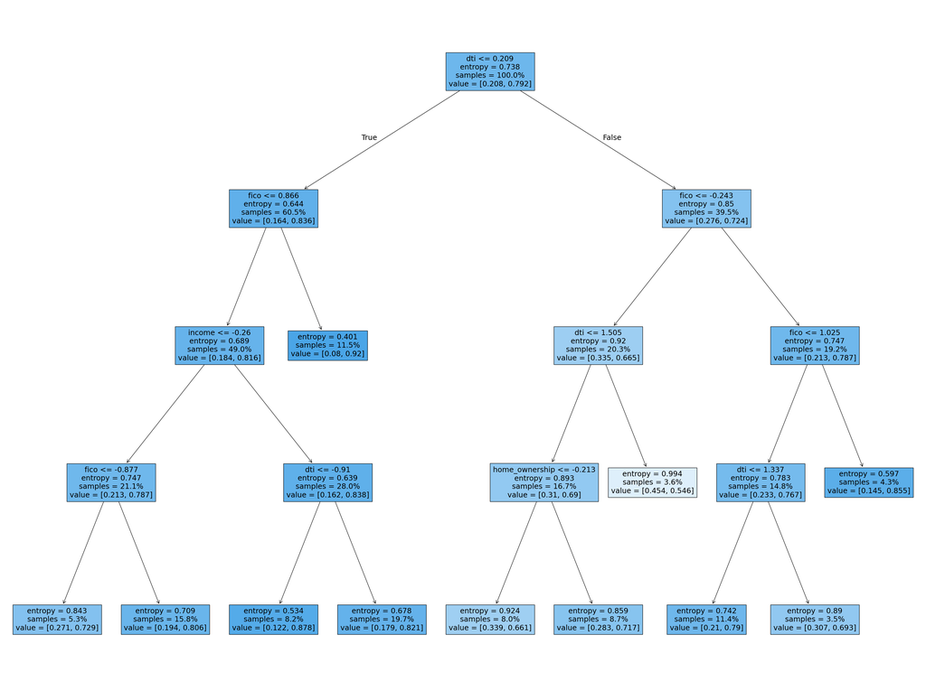

```python
clf = DecisionTreeClassifier(criterion='entropy',max_depth=4,min_samples_split=1000,min_samples_leaf=200,random_state=0)
clf = clf.fit(X_scaled_train,y_train)
fig, ax = plt.subplots(figsize=(40, 30))
plot_tree(clf, filled=True, feature_names=X_train.columns, proportion=True)
plt.show()
```